# Prep secondo parz

tommaso tarchi

2022-12-29

# Models

```r
library(PerformanceAnalytics)
library(mgcv)
library(splines)

data(trees)
```

We can give a first look at the data to check for patterns and dependencies:

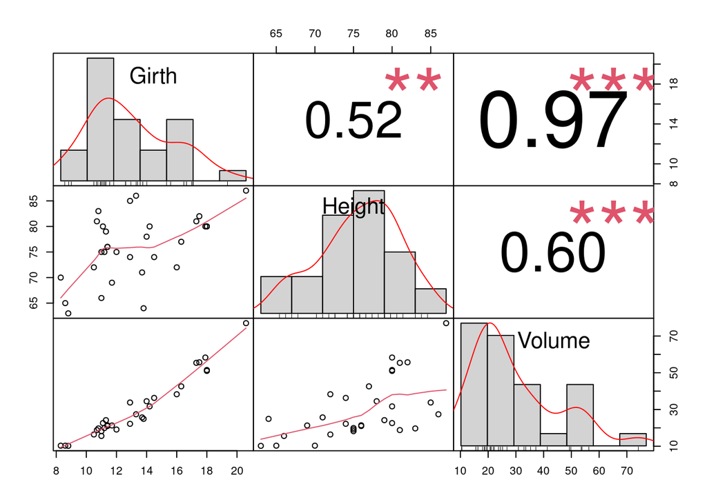

```r
chart.Correlation(trees)
```

We can also check for multicollinearity:

```r
round(cor(trees), 2)
```

```
##        Girth Height Volume
## Girth   1.00   0.52   0.97
## Height  0.52   1.00   0.60
## Volume  0.97   0.60   1.00
```

## Linear (or pseudo-linear) models

Let’s try to fit Volume as a function of Height (just as a first attempt) using a linear relation, a logarithmic relation and splines inside lm() (remember that to use non linear expressions of the variables we have to wrap the expression with the function I()):

```r
lm.lin <- lm(Volume ~ Height, data = trees)
lm.log <- lm(Volume ~ I(log(Height)), data = trees)
lm.sp1 <- lm(Volume ~ bs(Height), data = trees)
```

```r
summary(lm.lin)
```

```
##
## Call:
## lm(formula = Volume ~ Height, data = trees)
##
## Residuals:
##     Min      1Q  Median      3Q     Max
## -21.274  -9.894  -2.894  12.068  29.852
##
## Coefficients:
##             Estimate Std. Error t value Pr(>|t|)
## (Intercept) -87.1236    29.2731  -2.976 0.005835 **
## Height        1.5433     0.3839   4.021 0.000378 ***
## ---
## Signif. codes:  0 '***' 0.001 '**' 0.01 '*' 0.05 '.' 0.1 ' ' 1
##
## Residual standard error: 13.4 on 29 degrees of freedom
## Multiple R-squared:  0.3579, Adjusted R-squared:  0.3358
## F-statistic: 16.16 on 1 and 29 DF,  p-value: 0.0003784
```

```r
summary(lm.log)
```

```
##
## Call:
## lm(formula = Volume ~ I(log(Height)), data = trees)
##
## Residuals:
##     Min      1Q  Median      3Q     Max
## -20.876  -9.766  -2.511  12.198  31.078
##
## Coefficients:
##                Estimate Std. Error t value Pr(>|t|)
## (Intercept)     -461.31     124.17  -3.715 0.000862 ***
## I(log(Height))   113.58      28.69   3.959 0.000447 ***
## ---
## Signif. codes:  0 '***' 0.001 '**' 0.01 '*' 0.05 '.' 0.1 ' ' 1
##
## Residual standard error: 13.47 on 29 degrees of freedom
## Multiple R-squared:  0.3508, Adjusted R-squared:  0.3284
## F-statistic: 15.67 on 1 and 29 DF,  p-value: 0.0004473
```

```r
summary(lm.sp1)
```

```
##
## Call:
## lm(formula = Volume ~ bs(Height), data = trees)
##
## Residuals:
##     Min      1Q  Median      3Q     Max
## -22.361  -8.334  -4.023  11.577  25.725
##
## Coefficients:
##             Estimate Std. Error t value Pr(>|t|)
## (Intercept)   14.223      9.457   1.504   0.1442
## bs(Height)1    4.071     26.693   0.153   0.8799
## bs(Height)2   17.607     17.325   1.016   0.3185
## bs(Height)3   37.052     14.549   2.547   0.0169 *
## ---
## Signif. codes:  0 '***' 0.001 '**' 0.01 '*' 0.05 '.' 0.1 ' ' 1
##
## Residual standard error: 13.75 on 27 degrees of freedom
## Multiple R-squared:  0.3701, Adjusted R-squared:  0.3001
## F-statistic: 5.288 on 3 and 27 DF,  p-value: 0.005338
```

We now try to increase the degrees of freedom for the spline functions:

```r
lm.sp2 <- lm(Volume ~ bs(Height, df = 6), data = trees)
summary(lm.sp2)
```

```
##
## Call:
## lm(formula = Volume ~ bs(Height, df = 6), data = trees)
##
## Residuals:
##     Min      1Q  Median      3Q     Max
## -20.531  -7.206  -1.215   8.691  22.358
##
## Coefficients:
##                     Estimate Std. Error t value Pr(>|t|)
## (Intercept)           16.669     11.070   1.506  0.14516
## bs(Height, df = 6)1  -10.948     28.601  -0.383  0.70526
## bs(Height, df = 6)2   17.934     16.828   1.066  0.29715
## bs(Height, df = 6)3   -1.809     15.655  -0.116  0.90897
## bs(Height, df = 6)4   52.197     15.907   3.281  0.00315 **
## bs(Height, df = 6)5  -25.466     22.855  -1.114  0.27621
## bs(Height, df = 6)6   52.136     15.711   3.318  0.00288 **
## ---
## Signif. codes:  0 '***' 0.001 '**' 0.01 '*' 0.05 '.' 0.1 ' ' 1
##
## Residual standard error: 12.52 on 24 degrees of freedom
## Multiple R-squared:  0.5358, Adjusted R-squared:  0.4198
## F-statistic: 4.617 on 6 and 24 DF,  p-value: 0.002985
```

A bit better than the previous one.

From the previous paragraph we expect Girth to be more correlated with Volume. Let’s see:

```r
lm.alt <- lm(Volume ~ Girth, data = trees)
summary(lm.alt)
```

```
##
## Call:
## lm(formula = Volume ~ Girth, data = trees)
##
## Residuals:
##    Min     1Q Median     3Q    Max
## -8.065 -3.107  0.152  3.495  9.587
##
## Coefficients:
##             Estimate Std. Error t value Pr(>|t|)
## (Intercept) -36.9435     3.3651  -10.98 7.62e-12 ***
## Girth         5.0659     0.2474   20.48  < 2e-16 ***
## ---
## Signif. codes:  0 '***' 0.001 '**' 0.01 '*' 0.05 '.' 0.1 ' ' 1
##
## Residual standard error: 4.252 on 29 degrees of freedom
## Multiple R-squared:  0.9353, Adjusted R-squared:  0.9331
## F-statistic: 419.4 on 1 and 29 DF,  p-value: < 2.2e-16
```

As expected this fit is much better.

## Multilinear models

We can add variables and interaction (i.e. product) between variables (using ‘:’):

```r
lm.more <- lm(Volume ~ Height+Girth, data = trees)
lm.inter <- lm(Volume ~ Height+Girth+Height:Girth, data = trees)
```

```r
summary(lm.more)
```

```
##
## Call:
## lm(formula = Volume ~ Height + Girth, data = trees)
##
## Residuals:
##     Min      1Q  Median      3Q     Max
## -6.4065 -2.6493 -0.2876  2.2003  8.4847
##
## Coefficients:
##             Estimate Std. Error t value Pr(>|t|)
## (Intercept) -57.9877     8.6382  -6.713 2.75e-07 ***
## Height        0.3393     0.1302   2.607   0.0145 *
## Girth         4.7082     0.2643  17.816  < 2e-16 ***
## ---
## Signif. codes:  0 '***' 0.001 '**' 0.01 '*' 0.05 '.' 0.1 ' ' 1
##
## Residual standard error: 3.882 on 28 degrees of freedom
## Multiple R-squared:  0.948,  Adjusted R-squared:  0.9442
## F-statistic:   255 on 2 and 28 DF,  p-value: < 2.2e-16
```

```r
summary(lm.inter)
```

```
##
## Call:
## lm(formula = Volume ~ Height + Girth + Height:Girth, data = trees)
##
## Residuals:
##     Min      1Q  Median      3Q     Max
## -6.5821 -1.0673  0.3026  1.5641  4.6649
##
## Coefficients:
##              Estimate Std. Error t value Pr(>|t|)
## (Intercept)  69.39632   23.83575   2.911  0.00713 **
## Height       -1.29708    0.30984  -4.186  0.00027 ***
## Girth        -5.85585    1.92134  -3.048  0.00511 **
## Height:Girth  0.13465    0.02438   5.524 7.48e-06 ***
## ---
## Signif. codes:  0 '***' 0.001 '**' 0.01 '*' 0.05 '.' 0.1 ' ' 1
##
## Residual standard error: 2.709 on 27 degrees of freedom
## Multiple R-squared:  0.9756, Adjusted R-squared:  0.9728
## F-statistic: 359.3 on 3 and 27 DF,  p-value: < 2.2e-16
```

## Checking linear model’s assumptions graphically

We can use chart.Correlation() on the raw data (as we did in the beginning).

To visualize the stuff about the fit we can do:

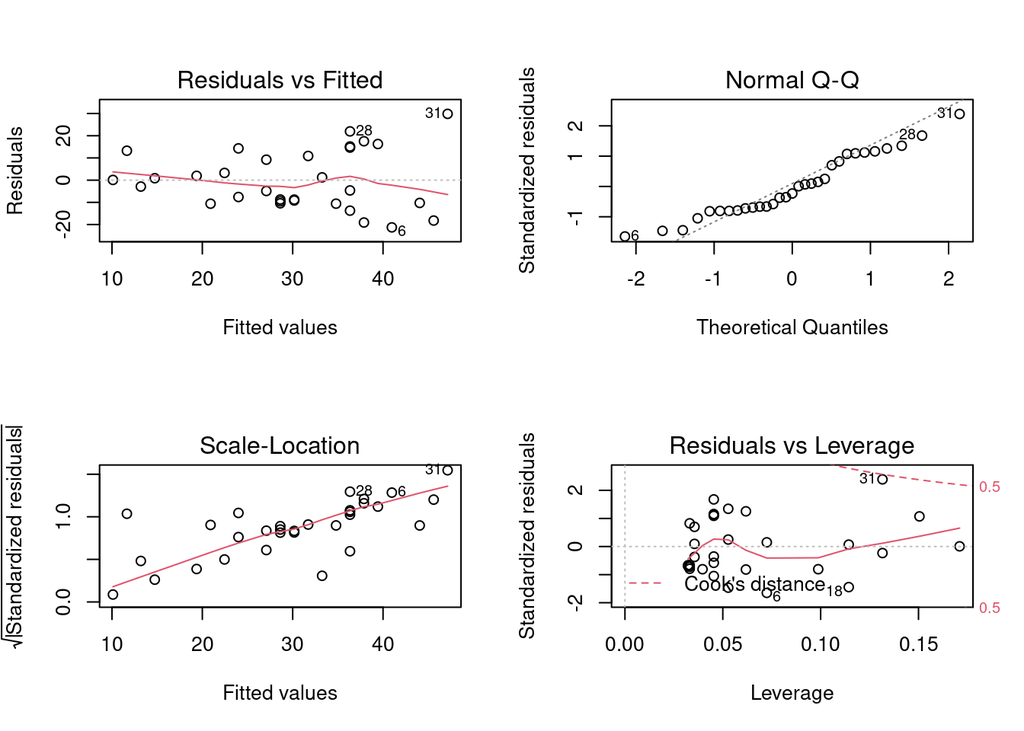

```r
par(mfrow = c(2, 2))
plot(lm.lin)
```

The first plot is useful to check linearity and also homoschedasticity. The second one to check normality of the stochastic component. The third one is a better way to check for homoscedasticity (in this situation we expect to see a roughly constant line about one). The fourth one is usually used to check for high-leverage outliers, which can be a problem during the estimation of the parameters; they can be recognized as the ones being out of the dashed red boundaries.

We can also do it for multilinear models:

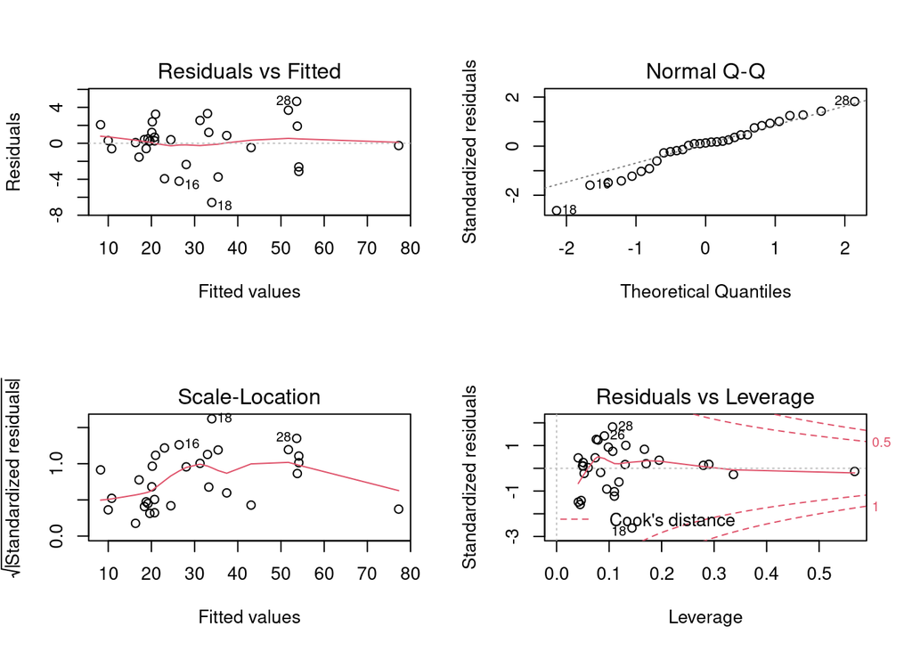

```r
par(mfrow = c(2, 2))
plot(lm.inter)
```

Another interesting plot to inspect is the index Vs residuals (i.e. the plot of the residuals ‘as found in the sample’). If a pattern seems to emerge from this analysis, there could be an autocorrelation among the variables (for example a time correlation).

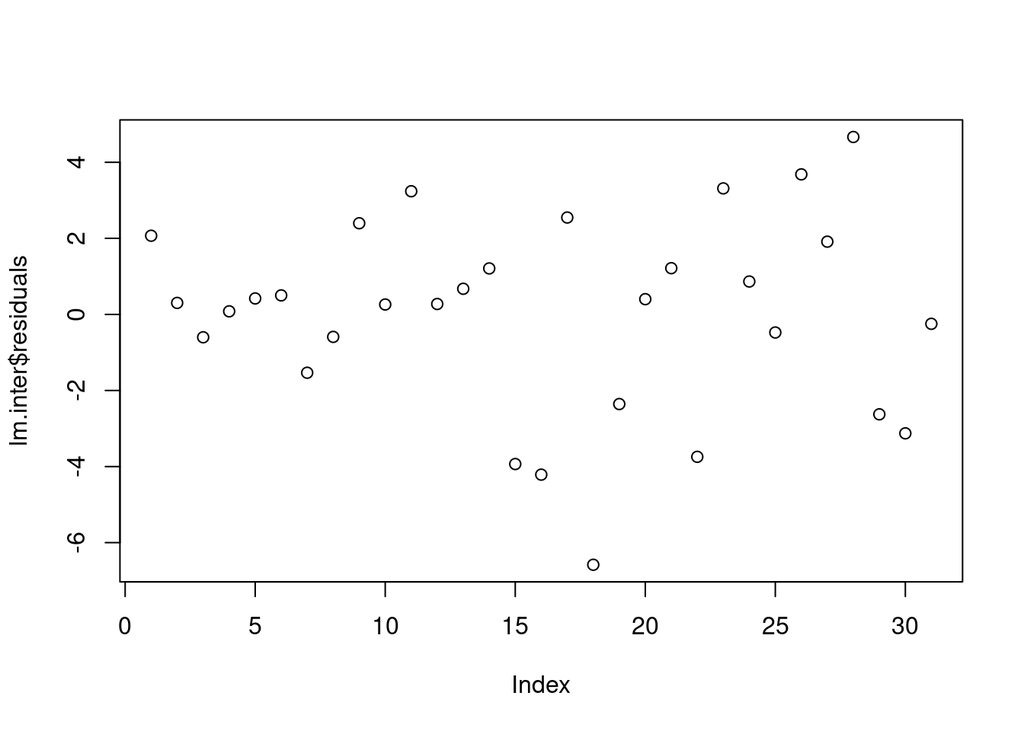

```r
plot(lm.inter$residuals)
```

Here we cannot see any apparent pattern.

## Generalized linear and additive models

First we try with a glm with gamma family (we cannot use Poisson family because Y is a continuous variable):

```r
glm.gamm <- glm(Volume ~ Height, data = trees, family = Gamma(link = "log"))
summary(glm.gamm)
```

```
##
## Call:
## glm(formula = Volume ~ Height, family = Gamma(link = "log"),
##     data = trees)
##
## Deviance Residuals:
##     Min       1Q   Median       3Q      Max
## -0.6719  -0.3199  -0.1358   0.3714   0.5801
##
## Coefficients:
##             Estimate Std. Error t value Pr(>|t|)
## (Intercept) -0.85467    0.88028  -0.971     0.34
## Height       0.05532    0.01154   4.792 4.52e-05 ***
## ---
## Signif. codes:  0 '***' 0.001 '**' 0.01 '*' 0.05 '.' 0.1 ' ' 1
##
## (Dispersion parameter for Gamma family taken to be 0.1622999)
##
##     Null deviance: 8.3172  on 30  degrees of freedom
## Residual deviance: 4.7723  on 29  degrees of freedom
## AIC: 239.67
##
## Number of Fisher Scoring iterations: 4
```

Let’s try now with gam:

```r
gam.gamm <- gam(Volume ~ s(Height), data = trees, family = Gamma(link = "log"))
summary(gam.gamm)
```

```
##
## Family: Gamma
## Link function: log
##
## Formula:
## Volume ~ s(Height)
##
## Parametric coefficients:
##             Estimate Std. Error t value Pr(>|t|)
## (Intercept)  3.34970    0.07236   46.29   <2e-16 ***
## ---
## Signif. codes:  0 '***' 0.001 '**' 0.01 '*' 0.05 '.' 0.1 ' ' 1
##
## Approximate significance of smooth terms:
##           edf Ref.df     F  p-value
## s(Height)   1      1 22.97 4.56e-05 ***
## ---
## Signif. codes:  0 '***' 0.001 '**' 0.01 '*' 0.05 '.' 0.1 ' ' 1
##
## R-sq.(adj) =  0.348   Deviance explained = 42.6%
## GCV = 0.17591  Scale est. = 0.1623    n = 31
```

We can analyze the AIC:

```r
c(AIC(lm.lin), AIC(lm.log), AIC(lm.sp1), AIC(lm.sp2), AIC(glm.gamm), AIC(gam.gamm))
```

```
## [1] 252.7986 253.1380 256.2044 252.7412 239.6724 239.7580
```

Notice that the fact that Height does not need the spline in glm (as we can see from the AIC values) is also suggested by the fact that in the gam.gamm summary the estimated degrees of freedom of s(Height) is equal to one.

## Adding predictors to generalized linear model

We now add the Girth variable to the two best models:

```r
glm.more <- glm(Volume ~ Height+Girth, data = trees, family = Gamma(link = "log"))
gam.more <- gam(Volume ~ s(Height)+s(Girth), data = trees, family = Gamma(link = "log"))
```

```r
summary(glm.more)
```

```
##
## Call:
## glm(formula = Volume ~ Height + Girth, family = Gamma(link = "log"),
##     data = trees)
##
## Deviance Residuals:
##      Min        1Q    Median        3Q       Max
## -0.17812  -0.08826  -0.01317   0.05635   0.17091
##
## Coefficients:
##             Estimate Std. Error t value Pr(>|t|)
## (Intercept) 0.092305   0.215868   0.428    0.672
## Height      0.016578   0.003252   5.097 2.13e-05 ***
## Girth       0.145281   0.006604  21.999  < 2e-16 ***
## ---
## Signif. codes:  0 '***' 0.001 '**' 0.01 '*' 0.05 '.' 0.1 ' ' 1
##
## (Dispersion parameter for Gamma family taken to be 0.009410213)
##
##     Null deviance: 8.31720  on 30  degrees of freedom
## Residual deviance: 0.26247  on 28  degrees of freedom
## AIC: 151.01
##
## Number of Fisher Scoring iterations: 4
```

```r
summary(gam.more)
```

```
##
## Family: Gamma
## Link function: log
##
## Formula:
## Volume ~ s(Height) + s(Girth)
##
## Parametric coefficients:
##             Estimate Std. Error t value Pr(>|t|)
## (Intercept)  3.27570    0.01492   219.6   <2e-16 ***
## ---
## Signif. codes:  0 '***' 0.001 '**' 0.01 '*' 0.05 '.' 0.1 ' ' 1
##
## Approximate significance of smooth terms:
##             edf Ref.df      F  p-value
## s(Height) 1.000  1.000  31.32 7.07e-06 ***
## s(Girth)  2.422  3.044 219.28  < 2e-16 ***
## ---
## Signif. codes:  0 '***' 0.001 '**' 0.01 '*' 0.05 '.' 0.1 ' ' 1
##
## R-sq.(adj) =  0.973   Deviance explained = 97.8%
## GCV = 0.0080824  Scale est. = 0.006899  n = 31
```

```r
c(AIC(glm.more), AIC(gam.more))
```

```
## [1] 151.0081 143.1907
```

We can see that the gam is better. We can still try to mix linear and spline contributes inside the additive model, and see if we get some improvement. From the estimated degrees of freedom in gam.more we expect to get a worse model mixing spline Height and linear Girth and to get a roughly equal (maybe slightly better) model mixing linear Height and spline Girth.

```r
gam.mix1 <- gam(Volume ~ s(Height)+Girth, data = trees, family = Gamma(link = "log"))
summary(gam.mix1)
```

```
##
## Family: Gamma
## Link function: log
##
## Formula:
## Volume ~ s(Height) + Girth
##
## Parametric coefficients:
##             Estimate Std. Error t value Pr(>|t|)
## (Intercept) 1.350148   0.087232   15.48 4.99e-15 ***
## Girth       0.145412   0.006458   22.52  < 2e-16 ***
## ---
## Signif. codes:  0 '***' 0.001 '**' 0.01 '*' 0.05 '.' 0.1 ' ' 1
##
## Approximate significance of smooth terms:
##             edf Ref.df    F  p-value
## s(Height) 1.737  2.166 13.3 8.06e-05 ***
## ---
## Signif. codes:  0 '***' 0.001 '**' 0.01 '*' 0.05 '.' 0.1 ' ' 1
##
## R-sq.(adj) =  0.953   Deviance explained = 97.1%
## GCV = 0.010076  Scale est. = 0.0089793  n = 31
```

```r
AIC(gam.mix1)
```

```
## [1] 150.212
```

```r
gam.mix2 <- gam(Volume ~ Height+s(Girth), data = trees, family = Gamma(link = "log"))
summary(gam.mix2)
```

```
##
## Family: Gamma
## Link function: log
##
## Formula:
## Volume ~ Height + s(Girth)
##
## Parametric coefficients:
##             Estimate Std. Error t value Pr(>|t|)
## (Intercept)  2.04669    0.22011   9.298 7.67e-10 ***
## Height       0.01617    0.00289   5.596 6.51e-06 ***
## ---
## Signif. codes:  0 '***' 0.001 '**' 0.01 '*' 0.05 '.' 0.1 ' ' 1
##
## Approximate significance of smooth terms:
##            edf Ref.df     F p-value
## s(Girth) 2.422  3.044 219.3  <2e-16 ***
## ---
## Signif. codes:  0 '***' 0.001 '**' 0.01 '*' 0.05 '.' 0.1 ' ' 1
##
## R-sq.(adj) =  0.973   Deviance explained = 97.8%
## GCV = 0.0080824  Scale est. = 0.006899  n = 31
```

```r
AIC(gam.mix2)
```

```
## [1] 143.1907
```

## GLM Vs GAM

Let’s see if there are any difference between glm and gam with linear contribution, by rewriting glm.more using the gam function:

```r
glm.more.fake <- gam(Volume ~ Height+Girth, data = trees, family = Gamma(link = "log"))
summary(glm.more.fake)
```

```
##
## Family: Gamma
## Link function: log
##
## Formula:
## Volume ~ Height + Girth
##
## Parametric coefficients:
##             Estimate Std. Error t value Pr(>|t|)
## (Intercept) 0.092303   0.215868   0.428    0.672
## Height      0.016578   0.003252   5.097 2.13e-05 ***
## Girth       0.145281   0.006604  21.999  < 2e-16 ***
## ---
## Signif. codes:  0 '***' 0.001 '**' 0.01 '*' 0.05 '.' 0.1 ' ' 1
##
##
## R-sq.(adj) =  0.941   Deviance explained = 96.8%
## GCV = 0.010378  Scale est. = 0.0094102  n = 31
```

```r
AIC(glm.more.fake)
```

```
## [1] 151.18
```

We see that the ‘fake’ glm and the true one are roughly the same (aside from a very small difference in the AIC).

The ‘opposite’ thing (i.e. if glm with splines) is not possible: glm cannot handle splines.

## s() and bs() splines

To see the difference between normal splines and B-splines, we build the same model with both:

```r
gam.more.s <- gam(Volume ~ s(Height)+s(Girth), data = trees, family = Gamma(link = "log"))
gam.more.bs <- gam(Volume ~ bs(Height)+bs(Girth), data = trees, family = Gamma(link = "log"))
```

```r
summary(gam.more.s)
```

```
##
## Family: Gamma
## Link function: log
##
## Formula:
## Volume ~ s(Height) + s(Girth)
##
## Parametric coefficients:
##             Estimate Std. Error t value Pr(>|t|)
## (Intercept)  3.27570    0.01492   219.6   <2e-16 ***
## ---
## Signif. codes:  0 '***' 0.001 '**' 0.01 '*' 0.05 '.' 0.1 ' ' 1
##
## Approximate significance of smooth terms:
##             edf Ref.df      F  p-value
## s(Height) 1.000  1.000  31.32 7.07e-06 ***
## s(Girth)  2.422  3.044 219.28  < 2e-16 ***
## ---
## Signif. codes:  0 '***' 0.001 '**' 0.01 '*' 0.05 '.' 0.1 ' ' 1
##
## R-sq.(adj) =  0.973   Deviance explained = 97.8%
## GCV = 0.0080824  Scale est. = 0.006899  n = 31
```

```r
summary(gam.more.bs)
```

```
##
## Family: Gamma
## Link function: log
##
## Formula:
## Volume ~ bs(Height) + bs(Girth)
##
## Parametric coefficients:
##             Estimate Std. Error t value Pr(>|t|)
## (Intercept)   2.2410     0.0655  34.215  < 2e-16 ***
## bs(Height)1   0.0306     0.1782   0.172  0.86513
## bs(Height)2   0.3667     0.1203   3.048  0.00553 **
## bs(Height)3   0.3076     0.1151   2.672  0.01332 *
## bs(Girth)1    0.8540     0.1680   5.083 3.37e-05 ***
## bs(Girth)2    1.3697     0.1340  10.225 3.18e-10 ***
## bs(Girth)3    1.7830     0.1354  13.165 1.79e-12 ***
## ---
## Signif. codes:  0 '***' 0.001 '**' 0.01 '*' 0.05 '.' 0.1 ' ' 1
##
##
## R-sq.(adj) =  0.974   Deviance explained = 97.9%
## GCV = 0.0093184  Scale est. = 0.0071727  n = 31
```

```r
c(AIC(gam.more.s), AIC(gam.more.bs))
```

```
## [1] 143.1907 146.9980
```

## Best model

To compare nested models the best thing is to use ANOVA (in R the anova() function). It is useful to understand the significance of every parameter (and so the weight of every predictor), and to choose the right degree of complexity of the model. Recall that to perform a test in anova() you MUST specify a test in the function’s parameters (test = “…”, usually “LR”).

To compare models of different ‘kind’ (for example a glm and a gam, or two glm with different error structures and links) the best tools are AIC and BIC. It doesn’t make sense to perform ANOVA on non nested models.

DIFFERENZA TRA S E BS IN GAM?

FARE UN GLM OPPURE FARE UN GAM SENZA S() È ESATTAMENTE LA STESSA COSA?